# Replace Venn diagrams with UpSetR

Chiara E. Cotroneo - R Ladies Dublin

# Before the workshop

Install the required libraries:

```r
install.packages("tidyverse")
install.packages("venn")
install.packages("UpSetR")

source("http://bioconductor.org/biocLite.R")
biocLite(c("graph", "RBGL"))
install.packages("reshape")
install.packages("Vennerable", repos="http://R-Forge.R-project.org")
```

Download the input dataset and R Markdown file [from my github](https://raw.githubusercontent.com/selenocysteine/r-ladies-dublin/master/introduction-upsetR) (optional).

# During the workshop

## Import the libraries

```r
# For general data manipulation and exploratory visualisation
library(tidyverse)

# To plot Venn diagrams
library(Vennerable)
library(venn)

# And, of course, UpSetR
library(UpSetR)
```

## Import the dataset

We can load the input dataset from my github:

```r
flags_data <- read.csv("https://raw.githubusercontent.com/selenocysteine/r-ladies-dublin/master/introduction-upsetR/data/flags.csv")
#flags_data <- read.csv("../data/flags.csv")
head(flags_data, 10)
```

```
##               country bars stripes red green blue gold white black orange
## 1             Albania    0       0   1     0    0    1     0     1      0
## 2             Andorra    3       0   1     0    1    1     0     0      0
## 3             Armenia    0       3   1     0    1    1     0     0      0
## 4             Austria    0       3   1     0    0    0     1     0      0
## 5          Azerbaijan    0       3   1     1    1    0     0     0      0
## 6             Belarus    0       2   1     1    0    0     0     0      0
## 7             Belgium    3       0   1     0    0    1     0     1      0
## 8  Bosnia Herzegovina    0       0   0     0    1    1     0     0      0
## 9            Bulgaria    0       3   1     1    1    1     1     0      0
## 10            Croatia    0       3   1     1    0    0     1     0      0
```

Each row of this dataset corresponds to the **flag** of a **country** that is (at least in part) geographically located in **Europe**. The columns correspond to 1 identifier variable (contry) and 9 measured variables:

- *country*: name of each country;
- *bars*: number of vertical sections on each flag (int);
- *stripes*: number of horizontal sections on each flag (int);
- *red*, *green*, *blue*, *gold*, *white*, *black*, *orange*: whether a colour is present on a flag or not (yes = 1, no = 0).

Let’s edit the dataset with a pet peeve of mine :)

```r
flags_data <- flags_data %>%
  dplyr::add_row(country = "European Union",
                 bars = 0,
                 stripes = 0,
                 red = 0,
                 green = 0,
                 blue = 1,
                 gold = 1,
                 white = 0,
                 black = 0,
                 orange = 0
                 )
```

Total number of flags in the dataframe:

```r
nrow(flags_data)
```

```
## [1] 51
```

The original source for this data is https://archive.ics.uci.edu/ml/datasets/Flags. However, the data available at this address is from the 80s (before of the fall of the Berlin Wall, the Yugoslav Wars, etc), so I manually updated it with information about more recent flags taken from https://en.wikipedia.org/wiki/Flags_of_Europe.

## (Fast) exploratory analysis of the dataset

Let’s give a quick view to the data contained in the dataset by making some **exploratory plots** with the **ggplot2** library (contained in the library *tidyverse*) to get a general idea of the general distribution of features (colours / bars / stripes) among flags.

**A tiny problem:** the input dataframe is in a **wide format** (1 column for the identifier (country) and 1 column per variable), while ggplot2 prefers a **narrow format** (1 column with an identifier (country), 1 column with variable names, 1 column with the value for each variable).

Thus, we start by **reshaping** the dataset into a **narrow format**, and by splitting it in two parts (quantitative vs binary attributes).

```r
# For the two quantitative variables (number of bars and number of stripes)
tidy_flags_data_quant <- flags_data %>%
  dplyr::select(country, bars, stripes) %>%
  tidyr::gather(type, number, -country)
head(tidy_flags_data_quant, 3)
```

```
##   country type number
## 1 Albania bars      0
## 2 Andorra bars      3
## 3 Armenia bars      0
```

```r
# For the seven binary variables (presence or absence of colours)
tidy_flags_data_col <- flags_data %>%
  dplyr::select(-c(bars, stripes)) %>%
  tidyr::gather(colour, value, -country) %>%
  # As this is binary data,
  # we don't need to keep track of the 0 values
  dplyr::filter(value > 0) %>%
  dplyr::select(-value) %>%
  # We sort the colours by frequency
  # (getting the most frequent ones first)
  dplyr::mutate(colour = forcats::fct_infreq(.$colour))

head(tidy_flags_data_col, 3)
```

```
##   country colour
## 1 Albania    red
## 2 Andorra    red
## 3 Armenia    red
```

We also define a **colour palette**, using some official hex colour codes from some european flags (because why not):

```r
flag_palette <- c("black" = "black",
                  "orange" = "#FF883E",
                  "red" = "#ce2b37",
                  "green" = "#009246",
                  "white" = "white",
                  "blue" = "#0055A4",
                  "gold" = "#FCD116")
```

First, let’s have a bird’s-eye view of the colours of the flags in the dataset:

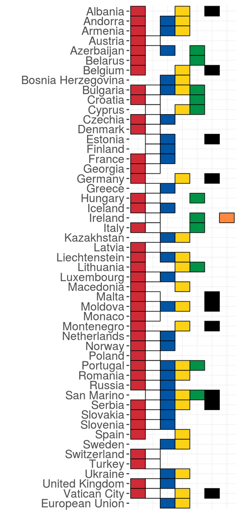

```r
tidy_flags_data_col %>%
  ggplot() +
  geom_tile(
    aes(x = country,
    y = colour,
    fill = colour),
    colour = "black",
    size = .3,
    show.legend = FALSE
    ) +
  scale_fill_manual(values = flag_palette) +
  # aesthetic tweaks
  theme_bw() +
  coord_flip() +
  scale_x_discrete(limits = rev(levels(tidy_flags_data_col$country))) +
  theme(text = element_text(size = 15),
        axis.line.x = element_blank(),
        axis.title.x = element_blank(),
        axis.text.x = element_blank(),
        axis.ticks.x = element_blank(),
        panel.grid = element_line(size = .2),
        panel.border = element_blank()) +
  xlab("")
```

Note that some flags have some symbols / drawings on them beside the traditional bars and stripes, hence the 4+ colours.

Now, another plot showing the amount of flags per each colour:

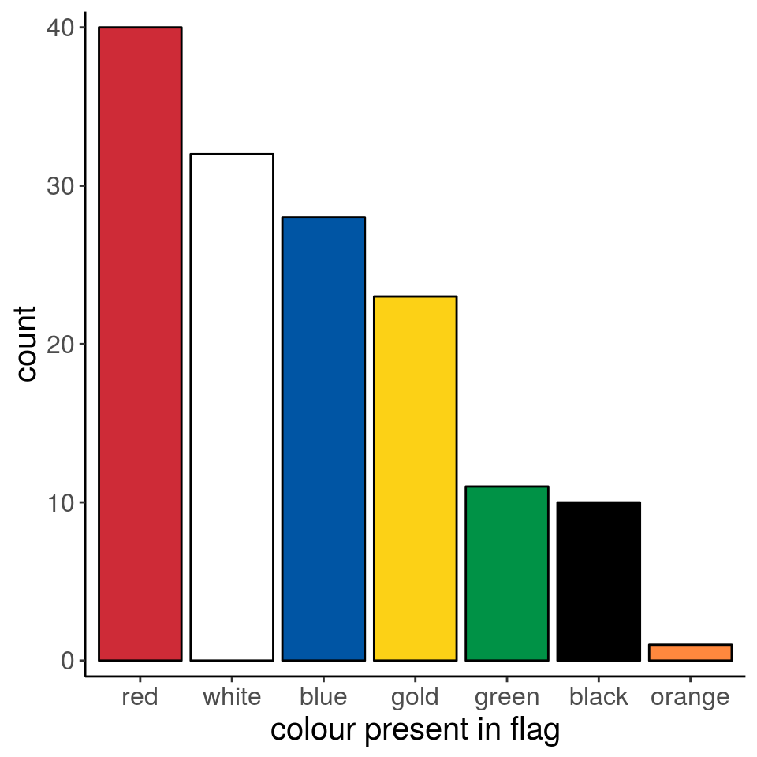

```r
tidy_flags_data_col %>%
  ggplot() +
  geom_bar(
    aes(x = colour,
    fill = colour),
    stat = "count",
    color = "black",
    position = "dodge",
    show.legend = FALSE
    ) +
  # aesthetic tweaks
  theme_classic() +
  scale_fill_manual(values = flag_palette) +
  scale_y_continuous(expand = c(0, 1)) +
  theme(text = element_text(size = 15)) +
  xlab("colour present in flag")
```

And last but not least, some information about bars and stripes (quantitative variable):

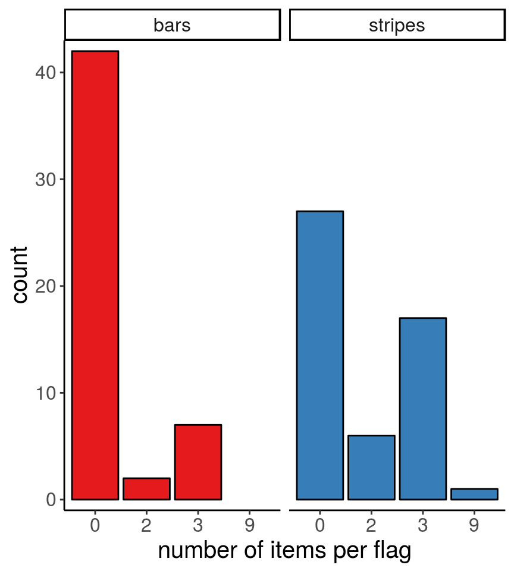

```r
tidy_flags_data_quant %>%
  ggplot() +
  geom_bar(aes(x = as.factor(number),
               fill = type),
           stat = "count",
           color = "black",
           show.legend = FALSE) +
  # aesthetic tweaks
  facet_grid(~ type) +
  theme_classic() +
  scale_fill_brewer(palette = "Set1") +
  xlab("number of items per flag") +
  scale_y_continuous(expand = c(0, 1)) +
  theme(text = element_text(size = 15))
```

## Find shared elements between groups in our data

Let’s say that we are interested in seeing how many European flags have both bars and stripes, or how many European flags contain the colour red, but also the colour white (at least, let’s pretend that this is an interesting scientific question :). This is a typical issue of finding intersections in our data, where some people would resort to something like a Venn diagram.

### Venn diagrams

#### Data preparation

Several R libraries for plotting Venn / Euler diagrams require a **list of vectors** as input. Each **vector** in the list has to correspond to a **set** (and contain all of its elements), and the name of each item in the list should correspond to the name of the corresponding set.

I just put here a bit of code that exploit the tidyverse library to quickly transform a binary, wide dataframe like *flags_data* into a list like this. Note that, for the two quantitative variables in our dataframe (*bars* and *stripes*), this code will just simplify each observation to “absence/presence”:

```r
# This procedure is a bit awkward and possibly not the smartest,
# you can visualise it step by step to get a sense of what it does
flags_list = flags_data %>%
    # Change the dataframe to a narrow format
    tidyr::gather(key, value, -country) %>%
    # Remove the rows with value = 0
    # (i.e. when a country does not belong to the set specified in key)
    dplyr::filter(value > 0) %>%
    # Remove the value column as it is not needed
    dplyr::select(-value) %>%
    # Group the data by key and create a new column
    # with all the countries that are associated to each key
    dplyr::group_by(key) %>%
    dplyr::do(data = as.character(.$country)) %>%
    # Convert to a named list of lists
    base::with(set_names(data, key))
```

Output:

```r
head(flags_list, 2)
```

```
## $bars
## [1] "Andorra"      "Belgium"      "France"       "Ireland"
## [5] "Italy"        "Malta"        "Moldova"      "Romania"
## [9] "Vatican City"
##
## $black
##  [1] "Albania"      "Belgium"      "Estonia"      "Germany"
##  [5] "Malta"        "Moldova"      "Montenegro"   "San Marino"
##  [9] "Serbia"       "Vatican City"
```

Let’s add a set representing flags with neither bars nor stripes:

```r
flags_list[["no sections"]] <- flags_data %>%
  dplyr::filter(bars == 0 & stripes == 0) %>%
  dplyr::pull(country) %>%
  as.character()
```

#### 3 sets examples, using the R libraries venn and Vennerable

Let’s show how many European flags have **both stripes and bars** with a simple Venn diagram generated with the **venn** library (note: this library also accepts binary dataframes, but we will use the previously generated list of vectors *flags_list*):

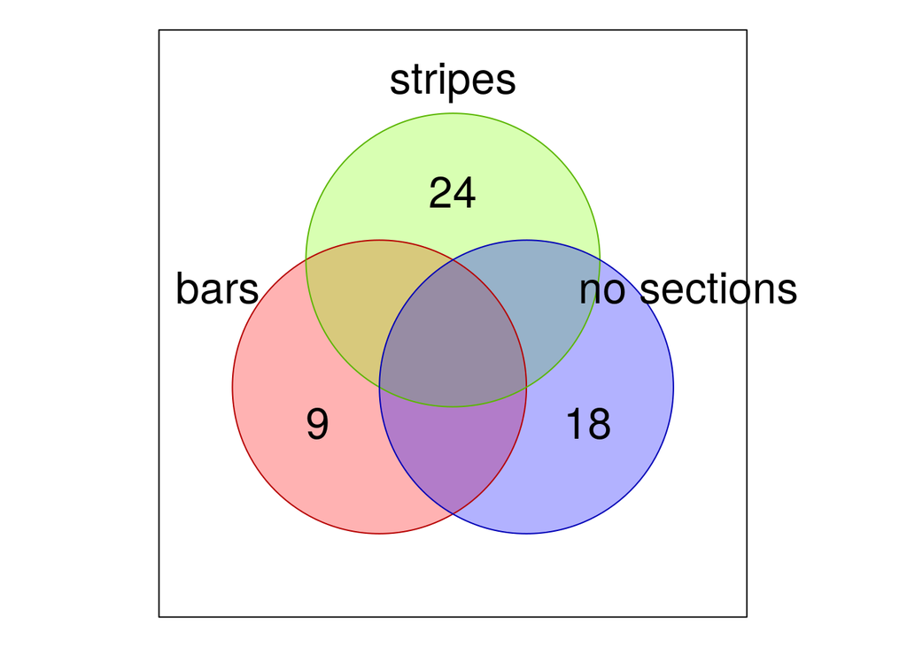

```r
#library(venn)
flags_list %>%
  # Extracting just the three sets of interest (flags with either bars, stripes, or neither)
  magrittr::extract(c("bars", "stripes", "no sections")) %>%
  venn::venn(zcolor = "style",
             # Increase font size for labels and values
             cexsn = 2,
             cexil = 2,
             borders = FALSE)
```

So, no European flags have both bars and stripes. In my opinion, this type of visualisation is not very informative, because: (i) the **areas** of the circles are **not proportional** to the number of items contained in them, (2) **empty intersections** is still **shown**.

We can replot this with the **Vennerable** library, that is a bit more flexible in some regards, for instance by allowing to draw **Euler plots** (not showing empty intersections), and to weight the area of each circle:

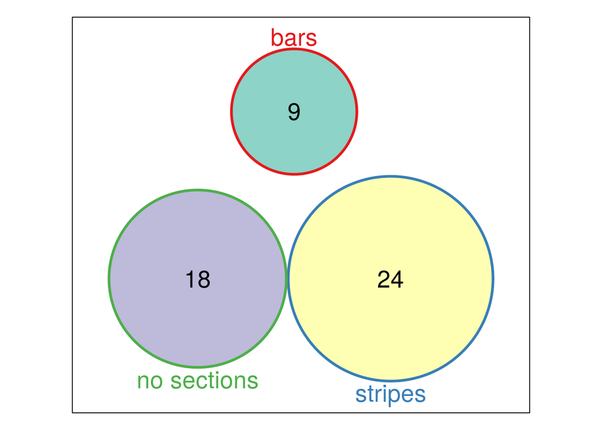

```r
#library(Vennerable)
flags_list %>%
  magrittr::extract(c("bars", "stripes", "no sections")) %>%
  # First, we have to create a Vennerable::Venn() object,
  # with the sizes of each intersection, and then we can plot it
  Vennerable::Venn() %>%
  plot(type = "circles",
       doWeights = TRUE,
       doEuler = TRUE)
```

This is a bit ugly, and Vennerable does not offer quick ways to customise the colours. However, it is a bit more informative than the Venn diagram, although we still have to read the numbers to really understand the sizes of the three sets.

### Multiple sets examples, using the R libraries venn and Vennerable

What if we are interested in seeing how the seven different colours are combined across the flags?

Vennerable can deal with a maximum of 5 subsets, so we can remove the least common colours (orange and black). However, we still get an unreadable result:

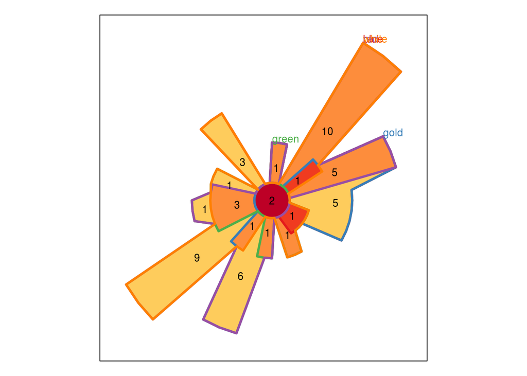

```r
#library(Vennerable)
flags_list %>%
  magrittr::extract(!(names(.) %in% c("bars", "stripes", "no sections", "orange", "black"))) %>%
  Vennerable::Venn() %>%
  plot()
```

The venn library is more optimised to deal with multiple sets. Here, we get something quite pretty. But does it really convey enough information to justify using a plot instead of a table? Is it easily readable or interpretable? (the answer is of course highly subjective).

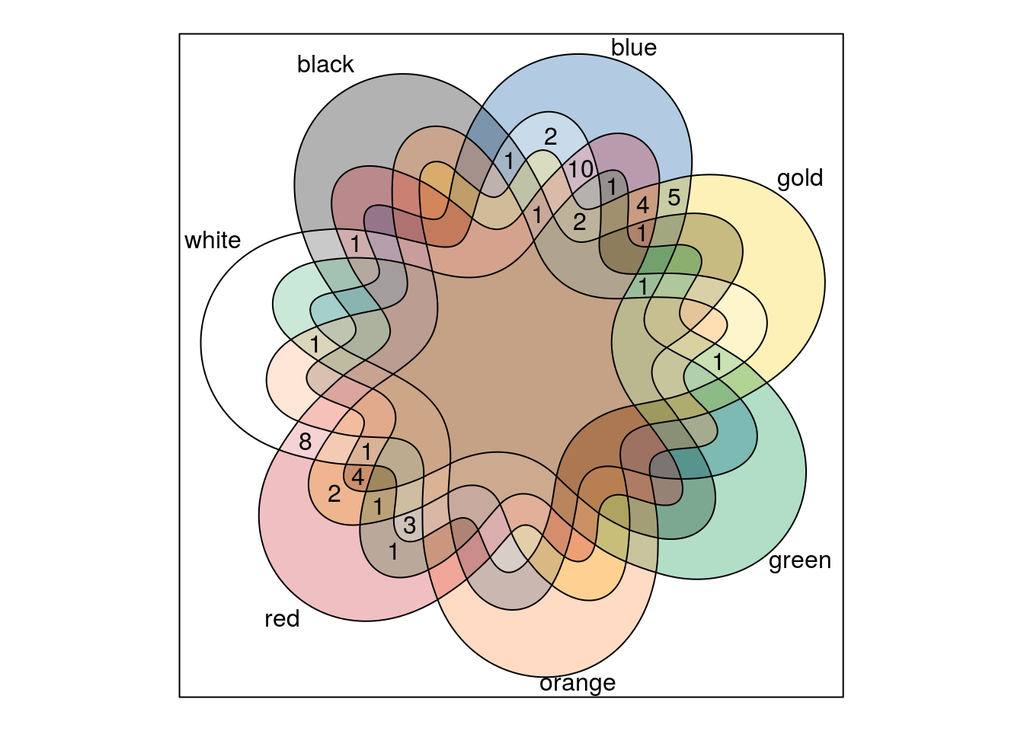

```r
#library(venn)
flags_list %>%
  magrittr::extract(!(names(.) %in% c("bars", "stripes", "no sections"))) %>%
  # the option zcolor can be used to set a predetermined colour for each subset;
  # the palette has to be in the same order as the list of sets, so we reorder it
  venn::venn(zcolor = flag_palette[names(.)],
             cexil = 1,
             cexsn = 1)
```

## Finally, UpSetR!

UpSetR is an R implementation of the upset plot format (originally invented by Lex *et al.*, [source](https://www.ncbi.nlm.nih.gov/pmc/articles/PMC4720993/)), that can be used for the visualisation of intersections of multiple sets. The UpsetR library was originally developed for the analysis of genomic data, and published in the journal *Bioinformatics* in 2017 ([source](https://academic.oup.com/bioinformatics/article/33/18/2938/3884387)).

The vignettes, available at https://cran.r-project.org/web/packages/UpSetR/README.html, illustrate its usage more in detail. There are still some bugs and awkward features, but it is overall promising and already useful.

We can use as an input our initial **binary dataframe** *flags_data*. Note that UpsetR is smart enough to automatically **ignore non-binary columns** and treat them as **metadata** (attributes) of each datapoint:

```r
head(flags_data, 5)
```

```
##      country bars stripes red green blue gold white black orange
## 1    Albania    0       0   1     0    0    1     0     1      0
## 2    Andorra    3       0   1     0    1    1     0     0      0
## 3    Armenia    0       3   1     0    1    1     0     0      0
## 4    Austria    0       3   1     0    0    0     1     0      0
## 5 Azerbaijan    0       3   1     1    1    0     0     0      0
```

Just by plotting our flag colours with default options, we already get a much clearer outline of the combinations of different colours in our European flags:

```r
#library(UpSetR)
upset(
  flags_data,
  # Careful: we have to manually specify how many subsets
  # we want to display (we can also specify them by column name),
  # and also set nintersects to NA if we are interested in all (non-empty)
  # intersections. It is still a bit fuzzy when it has to display empty intersections
  # on so many sets, but there is an option to do that, if wanted.
  nsets = ncol(flags_data) - 3,
  nintersects = NA,
  # Display them from the most numerous intersection to the least
  order.by = "freq",
  line.size = 1.2,
  point.size = 3.5,
  text.scale = 2
)
```

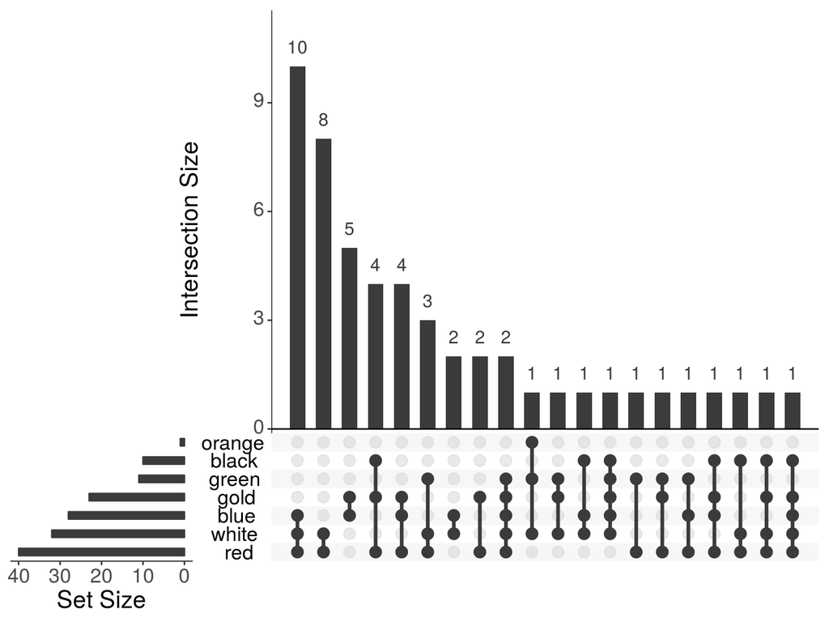

The plot is highly costumisable (you can edit the colour of the bars and of the dots matrix, etc). An outline of the different options is given, as usual, by typing the command:

```r
?upset
```

One of the interesting features of UpSetR is the **annotation** of the different intersections with **metadata**. The process is a bit awkward and often requires defining a specific filter functions (see the vignettes for further details), but very handy in some cases. For instance, we can define a filter function that identifies all the flags that have bars or stripes:

```r
find_bars_or_stripes <- function(row, pattern) {
  # 'pattern' is either "bars" or "stripes"
  data <- (row[pattern] > 0)
}
```

We can get an annotated plot that shows the position of flags with bars by running the following code. Note that, although it is possible to use multiple filters on the same plot, the overlaps between different filters that match the same intersections are not very well implemented yet, so it is usually safer to filter 1 variable at a time (e.g. in this case we cannot display striped and barred flags at the same time).

```r
#library(UpSetR)
upset(
  flags_data,
  nsets = ncol(flags_data) - 3,
  nintersects = NA,
  order.by = "freq",
  text.scale = 2,
  line.size = 1.2,
  point.size = 3.5,
  # Ask to display the legend
  query.legend = "top",
  # Annotation filters
  queries = list(
    # Here we specify that the params of our filter (the pattern argument)
    # is bars
    list(
      query = find_bars_or_stripes,
      params = list("bars"),
      color = "orange",
      query.name = "Flags with bars",
      active = T
    )
  )
)
```

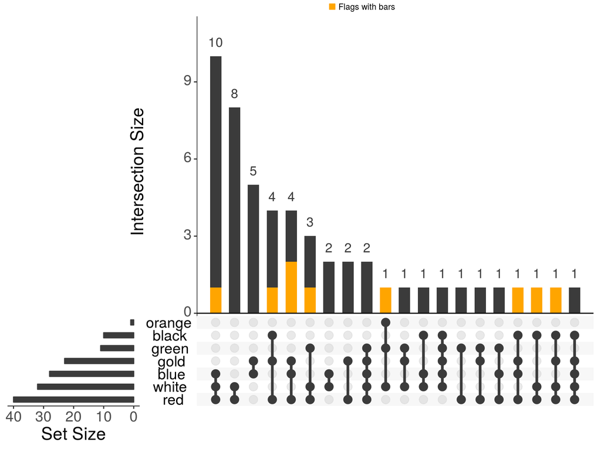

We can also look for specific items by name using the filter function pre-defined in UpSetR called *element* and draw a point (sadly, with random height…) on the bar corresponding to the intersection containing these items. For instance, let’s find the alpine European countries (countries that cover a portion of the Alps) and Ireland :)!

```r
#library(UpSetR)

alpine_countries <- c("Austria",
                     "Switzerland",
                     "Liechtenstein",
                     "Slovenia",
                     "Germany",
                     "France",
                     "Italy")

upset(
  flags_data,
  nsets = ncol(flags_data) - 3,
  nintersects = NA,
  order.by = "freq",
  text.scale = 2,
  line.size = 1.2,
  point.size = 3.5,
  query.legend = "top",
  queries = list(
    list(
      query = find_bars_or_stripes,
      params = list("bars"),
      color = "orange",
      query.name = "Flags with bars",
      active = T
    ),
    list(
      query = elements,
      params = list("country", "Ireland"),
      color = "darkgreen",
      query.name = "Ireland",
      active = F
    ),
    list(
      query = elements,
      params = list("country", alpine_countries),
      color = "red",
      query.name = "Alpine countries",
      active = F
    )
  )
)
```

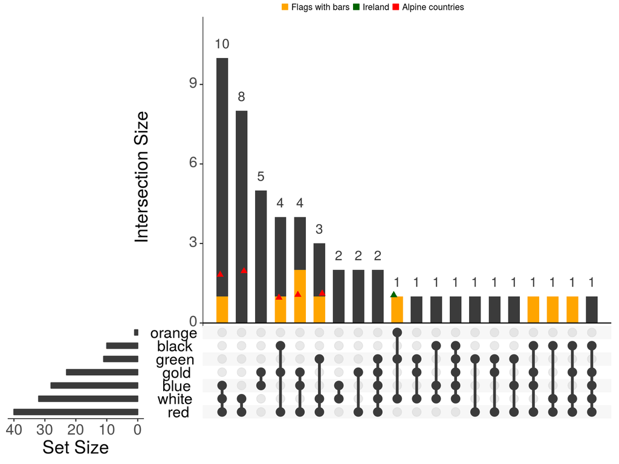

## Appendix

Some code to transform a list of sets (like the ones venn plotting libraries usually like) into a binary dataframe:

```r
new_flags_data <- melt(flags_list) %>%
  magrittr::set_colnames(c("country", "key")) %>%
  dplyr::group_by(country, key) %>%
  dplyr::mutate(value = 1)  %>%
  tidyr::spread(key, value, fill = 0)
head(new_flags_data, 5)
```

```
## # A tibble: 5 x 11
## # Groups:   country [5]
##   country  bars black  blue  gold green `no sections` orange   red stripes
##   <fct>   <dbl> <dbl> <dbl> <dbl> <dbl>         <dbl>  <dbl> <dbl>   <dbl>
## 1 Andorra     1     0     1     1     0             0      0     1       0
## 2 Belgium     1     1     0     1     0             0      0     1       0
## 3 France      1     0     1     0     0             0      0     1       0
## 4 Ireland     1     0     0     0     1             0      1     0       0
## 5 Italy       1     0     0     0     1             0      0     1       0
## # ... with 1 more variable: white <dbl>
```

Thanks to [Jean Manguy](https://jean.manguy.eu/) for feedback and helpful R suggestions.